# Countywide Town Hall Report

Advancement Project California

## Overview of Response Rates

#### Self-Response Rates as of 05/26

| State | County | HTC Census Tracts |
| --- | --- | --- |
| 61.3% | 56.5% | 50% |

### Response Rate by Primary HTC Characteristic

#### All Census Tracts

- Looking at the top HTC characteristics in all census tracts, the most common top HTC characteristic is multi-unit structures, followed by foreign born population and crowded units.
- In census tracts where the top HTC characteristic is lack of internet access, we see about 50% of households have responded so far. This is the current HTC group with the lowest response rate.
- In census tracts where the top HTC characteristic is moved recently, we see that a little more than 66% of households have responded. This is the HTC group with the highest response rate.

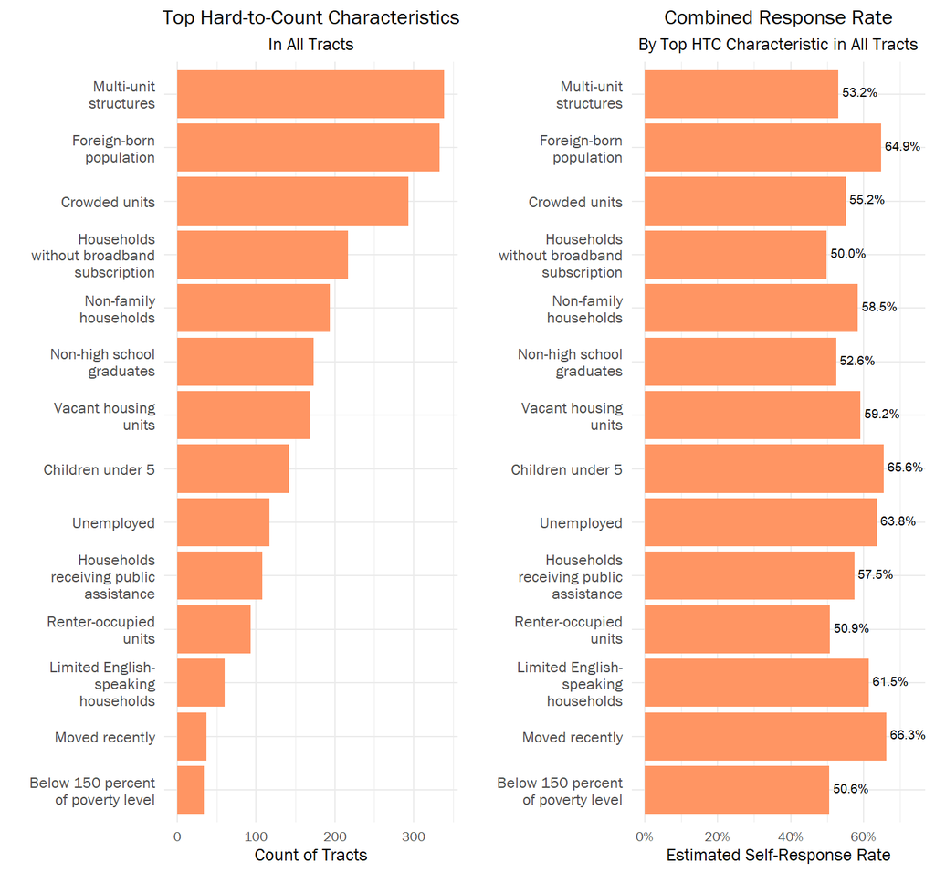

### Countywide: Response Rate in Communities by Demographic

- **Data Note:** We do not have data on who is responding to the Census, we only know the number of households that have responded in each tract.
- For these plots, we identified the census tracts with a high share (highest quintile) of each demographic group. For example, in 20% of census tracts in LA County the tract population is 11.2% Black or higher. These tracts make up the top quintile of census tracts for the Black population. The response rates for all the census tracts in the top quintile for the Black population are shown below.

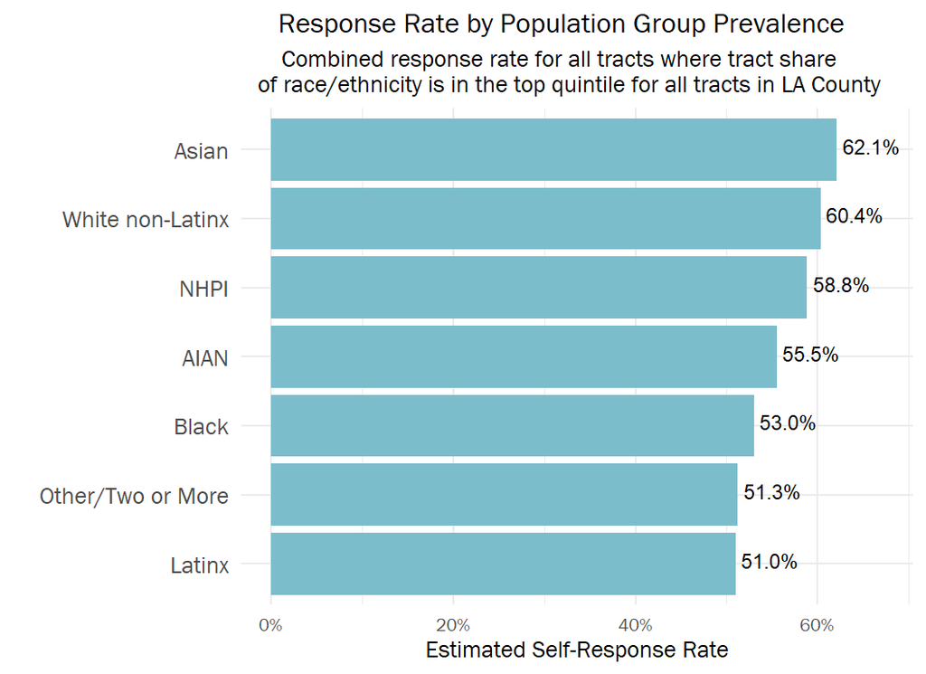

- The top 20% of census tracts for % Latinx population have a combined response rate of 51%. This is the lowest combined self-response rate in the county.
- Similarly, the top 20% of census tracts for % Black population have a combined response rate of 53%.
- Communities with large Latinx and Black populations have a greater concentration of hard-to-count tracts, which is reflected in these response rate estimates.

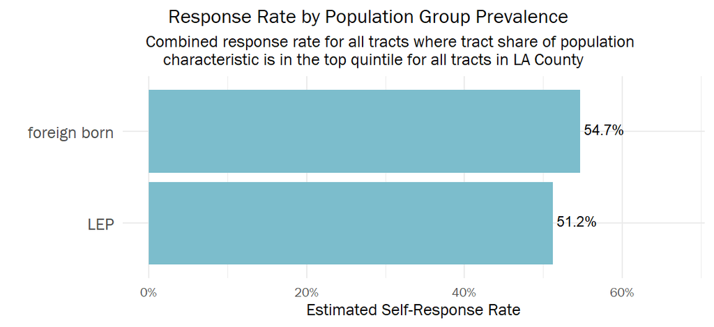

- In top 20% of census tracts for the foreign born population, the combined self-response rate is estimated to be nearly 55%.
- In the top 20% of census tracts for the limited English proficient population, the combined self-response rate is just over 51%.

### Regions: Response Rate in Communities by Demographic

- **Data Note:** We do not have data on who is responding to the Census, we only know the number of households that have responded in each tract.
- For these plots, we identified the census tracts with a high share (top 20%) of each demographic group. For example, in 20% of census tracts in LA County the Black population makes up 11.2% or higher of the total population. This is the top quintile of census tracts for the Black population. The response rates for all the census tracts in the top quintile for the Black population within each region are shown below.
- The concentration of HTC census tracts varies greatly across the county. Some regions have more than 150 HTC tracts, some regions have less than 20. Self-response rate varies widely across the county as well. South LA, Central LA and Northeast/Eastside LA are currently the lowest-responding regions, and also have the greatest concentration of hard-to-count census tracts.
- HTC characterstics, such as access to internet, vary across the county.

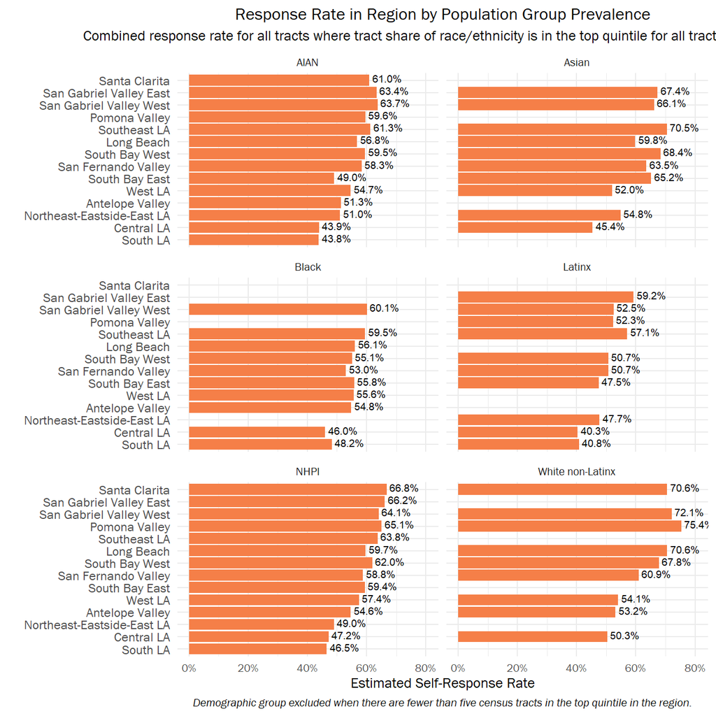

- Response rates in top-quintile census tracts by demographic group also varies by region. While we see that countywide, top-quintile Black tracts have a response rate of 53%, in South LA top-quintile Black tracts have a response rate of 48%, while in SGV West top-quintile Black tracts have a response rate of 60.1%.
- Countywide, top-quintile Latinx tracts have a response rate of 51%, in Central LA top-quintile Latinx tracts have a response rate of a little over 40%, while in SGV East top-quintile Latinx tracts have a response rate of 59.2%.
- **Urgent outreach target:** All people living in South LA, Central LA and NELA. Antelope Valley is also falling behind.

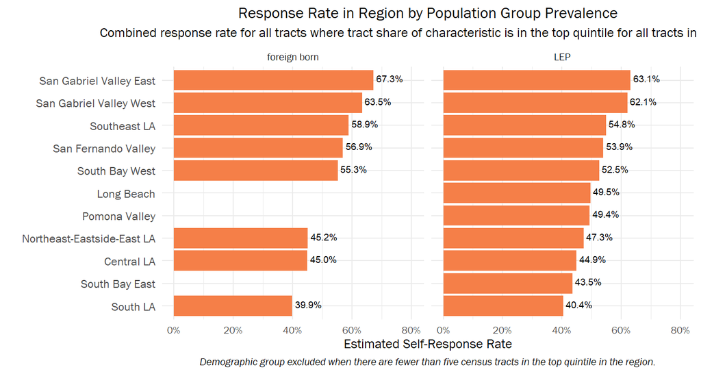

- Countywide, top-quintile foreign born tracts have a response rate of 54.7%. In San Gabriel Valley East, 67.3% of households in these tracts have respond, as compared to just under 40% of households in these tracts in South LA.
- **Priority outreach target:** People who were born outside of the US living in South LA, Central and NELA.
- **Priority outreach target:** People who don’t speak English well living in South LA, South Bay East, Central LA, NELA, Pomona Valley and Long Beach.

## What are Priority Communities by Demographics?

Priority communities are determined by calculating the combined self-response rate for census tracts that are in the top quintile for various demographics (for example, the top 20% of limited English proficient census tracts). Census tracts where more than half of the population lives in group quarters have been excluded.

- Priority communities for targeting outreach to limited English proficient speakers & people born outside of the US are located in Central and South LA.
- These communities have low self-response rates in tracts where the share of LEP and foreign born populations are in the highest quintile.
- Central-Alameda, Historic South-Central and Pico-Union are priority communities for both people who don’t speak English well and for people who were born outside the US.

| Priority communities for LEP population |
| --- |
| Central-Alameda |
| Historic South-Central |
| Pico-Union |
| South Park |
| Watts |

| Priority communities for foreign born population |
| --- |
| Central-Alameda |
| Chinatown |
| Historic South-Central |
| Pico-Union |
| University Park |

#### Priority communities by race/ethnicity

Many priority communities for targeting outreach to various demographic groups are located in South LA and Central LA, as these regions have the lowest overall self-response rates.

1. Central-Alameda and Historic South-Central in South LA is a priority community for Latinx and American Indian/Alaskan Native (AIAN) people living in low-responding tracts.
2. Downtown LA is a priority community for Black, Asian and Native Hawaiian/Pacific Islander (NHPI) populations living in low-responding tracts.
3. Pico-Union is a priority community for Asian, Latinx and American Indian/Alaskan Native (AIAN) people living in low-responding tracts.
4. Westlake is a priority community for Latinx and NHPI populations.

| Priority communities for AIAN population |
| --- |
| Central-Alameda |
| Harvard Heights |
| Historic South-Central |
| Northeast Antelope Valley |
| Pico-Union |

| Priority communities for Asian population |
| --- |
| Downtown |
| Harvard Heights |
| Lincoln Heights |
| Pico-Union |
| Westwood |

| Priority communities for Black population |
| --- |
| Downtown |
| Hollywood |
| South Park |
| Watts |
| Westchester |

| Priority communities for Latinx population |
| --- |
| Central-Alameda |
| Historic South-Central |
| Pico-Union |
| South Park |
| Westlake |

| Priority communities for NHPI population |
| --- |
| Boyle Heights |
| Downtown |
| Koreatown |
| Westlake |
| Wilmington |

## Priority Communities by Region

- We have identified priority communities in each region across the country. In regions with more HTC communities we have identified up to 5 communities per region.
- Priority communities were identified using four combined metrics: response rate, number of uncounted households, number of HTC tracts in the region, and the community mean HTC score.
- In each community we have identified the top HTC characteristic.

#### South LA-South Bay

| Region | Community | Top HTC Characteristic | Response Rate | Uncounted Households | Count of HTC Tracts in Community |
| --- | --- | --- | --- | --- | --- |
| South Bay East | East Compton | Non-high school graduates | 44.6% | 906 | 2 |
| South Bay East | Willowbrook | Non-high school graduates | 46.1% | 4847 | 5 |
| South Bay East | Wilmington | Crowded units | 46.8% | 7539 | 13 |
| South Bay East | Compton | Households receiving public assistance | 55.5% | 10668 | 13 |
| South Bay West | Lennox | Non-high school graduates | 48.6% | 2713 | 5 |
| South Bay West | Harbor Gateway | Crowded units | 54.9% | 5603 | 7 |
| South Bay West | San Pedro | Unemployed | 55.1% | 13985 | 10 |
| South Bay West | Inglewood | Multi-unit structures | 55.1% | 16435 | 15 |
| South Bay West | Hawthorne | Renter-occupied units | 57.5% | 12444 | 14 |
| South LA | Historic South-Central | Crowded units | 34.4% | 7322 | 12 |
| South LA | Central-Alameda | Non-high school graduates | 37.6% | 6145 | 10 |
| South LA | Watts | Non-high school graduates | 42.4% | 5606 | 8 |
| South LA | Florence | Non-high school graduates | 42.5% | 7221 | 13 |
| South LA | Florence-Firestone | Non-high school graduates | 45.8% | 8386 | 14 |

#### Metro LA

| Region | Community | Top HTC Characteristic | Response Rate | Uncounted Households | Count of HTC Tracts in Community |
| --- | --- | --- | --- | --- | --- |
| Central LA | Downtown | Multi-unit structures | 34.1% | 18655 | 13 |
| Central LA | Pico-Union | Renter-occupied units | 38.6% | 8491 | 14 |
| Central LA | Hollywood | Renter-occupied units | 42.2% | 22170 | 21 |
| Central LA | Westlake | Multi-unit structures | 42.2% | 22039 | 29 |
| Central LA | Koreatown | Multi-unit structures | 47% | 21743 | 30 |
| Northeast-Eastside-East LA | Lincoln Heights | Limited English-speaking households | 42.8% | 4181 | 6 |
| Northeast-Eastside-East LA | Boyle Heights | Households without broadband subscription | 44.6% | 13522 | 25 |
| Northeast-Eastside-East LA | El Sereno | Households without broadband subscription | 48.1% | 6004 | 6 |
| Northeast-Eastside-East LA | Highland Park | Unemployed | 49.5% | 8373 | 7 |
| Northeast-Eastside-East LA | East Los Angeles | Non-high school graduates | 51.1% | 15004 | 26 |
| West LA | Westwood | Non-family households | 42.4% | 10722 | 5 |
| West LA | Pico-Robertson | Non-family households | 48.8% | 4235 | 2 |
| West LA | Palms | Multi-unit structures | 57% | 9193 | 2 |

#### AV-SC

| Region | Community | Top HTC Characteristic | Response Rate | Uncounted Households | Count of HTC Tracts in Community |
| --- | --- | --- | --- | --- | --- |
| Antelope Valley | Lancaster | Below 150 percent of poverty level | 55.2% | 21347 | 9 |
| Antelope Valley | Palmdale | Non-high school graduates | 55.8% | 19399 | 9 |
| Santa Clarita | Santa Clarita | Multi-unit structures | 67% | 22302 | 3 |

#### SFV

| Region | Community | Top HTC Characteristic | Response Rate | Uncounted Households | Count of HTC Tracts in Community |
| --- | --- | --- | --- | --- | --- |
| San Fernando Valley | Pacoima | Non-high school graduates | 48.2% | 9532 | 16 |
| San Fernando Valley | Van Nuys | Multi-unit structures | 50.7% | 17291 | 24 |
| San Fernando Valley | North Hollywood | Multi-unit structures | 51.6% | 14497 | 18 |
| San Fernando Valley | Canoga Park | Multi-unit structures | 52.5% | 10359 | 10 |
| San Fernando Valley | Panorama City | Foreign-born population | 55.6% | 8714 | 15 |

#### Long Beach

| Region | Community | Top HTC Characteristic | Response Rate | Uncounted Households | Count of HTC Tracts in Community |
| --- | --- | --- | --- | --- | --- |
| Long Beach | Washington | Renter-occupied units | 47.6% | 1160 | 2 |
| Long Beach | Downtown/Central | Renter-occupied units | 48% | 1582 | 2 |
| Long Beach | AOC7 | Crowded units | 49.3% | 2072 | 3 |
| Long Beach | Wilmore | Multi-unit structures | 49.6% | 3961 | 5 |
| Long Beach | Cambodia Town | Crowded units | 52.4% | 2489 | 4 |

#### SELA

| Region | Community | Top HTC Characteristic | Response Rate | Uncounted Households | Count of HTC Tracts in Community |
| --- | --- | --- | --- | --- | --- |
| Southeast LA | Huntington Park | Crowded units | 50% | 7288 | 17 |
| Southeast LA | Maywood | Households without broadband subscription | 53.7% | 3100 | 7 |
| Southeast LA | Lynwood | Non-high school graduates | 54.1% | 7147 | 10 |
| Southeast LA | Bell Gardens | Non-high school graduates | 55.2% | 4329 | 9 |
| Southeast LA | South Gate | Non-high school graduates | 59.5% | 9690 | 17 |

#### SGV-Pomona

| Region | Community | Top HTC Characteristic | Response Rate | Uncounted Households | Count of HTC Tracts in Community |
| --- | --- | --- | --- | --- | --- |
| Pomona Valley | Pomona | Non-high school graduates | 56.7% | 16940 | 15 |
| San Gabriel Valley East | South San Jose Hills | Non-high school graduates | 53.6% | 2422 | 2 |
| San Gabriel Valley East | La Puente | Non-high school graduates | 60.6% | 3671 | 3 |
| San Gabriel Valley East | Baldwin Park | Foreign-born population | 65.7% | 6126 | 5 |
| San Gabriel Valley West | South El Monte | Households without broadband subscription | 55.6% | 2291 | 4 |
| San Gabriel Valley West | El Monte | Foreign-born population | 58% | 12418 | 20 |
| San Gabriel Valley West | Rosemead | Limited English-speaking households | 65.7% | 5046 | 5 |
| San Gabriel Valley West | Alhambra | Foreign-born population | 67.6% | 9534 | 8 |

Published by [Advancement Project California](https://www.advancementprojectca.org/)

[figure not shown]